# Geometry Data Operations and Troubleshooting

HES 505 Fall 2025: Session 11

Matt Williamson

## The Vector Data Model

- Coordinates define the **Vertices** (i.e., discrete x-y locations) that comprise the geometry
- The organization of those vertices define the *shape* of the vector
- General types: points, lines, polygons

[figure not shown]

## Representing vector data in R

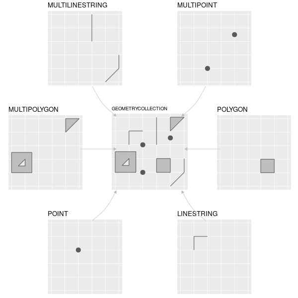

From Lovelace et al.

- `sf` hierarchy reflects increasing complexity of geometry
  - `st_point`, `st_linestring`, `st_polygon` for single features
  - `st_multi*` for multiple features of the same type
  - `st_geometrycollection` for multiple feature types
  - `st_as_sfc` creates the geometry list column for many `sf` operations

## Revisiting Simple Features

- The `sf` package relies on a simple feature data model to represent geometries
  - hierarchical
  - standardized methods
  - complementary binary and human-readable encoding

| type | description |
| --- | --- |
| `POINT` | single point geometry |
| `MULTIPOINT` | set of points |
| `LINESTRING` | single linestring (two or more points connected by straight lines) |
| `MULTILINESTRING` | set of linestrings |
| `POLYGON` | exterior ring with zero or more inner rings, denoting holes |
| `MULTIPOLYGON` | set of polygons |
| `GEOMETRYCOLLECTION` | set of the geometries above |

## Standaridized Methods

We can categorize `sf` operations based on what they return and/or how many geometries they accept as input.

- *Output Categories*
  - **Predicates**: evaluate a logical statement asserting that a property is `TRUE`
  - **Measures**: return a numeric value with units based on the units of the CRS
  - **Transformations**: create new geometries based on input geometries.
- *Input Geometries*
  - **Unary**: operate on a single geometry at a time (meaning that if you have a `MULTI*` object the function works on each geometry individually)
  - **Binary**: operate on pairs of geometries
  - **n-ary**: operate on sets of geometries

## Common Problems with Vector Data

- Vectors and scale
- Slivers and overlaps
- Undershoots and overshoots
- Self-intersections and rings

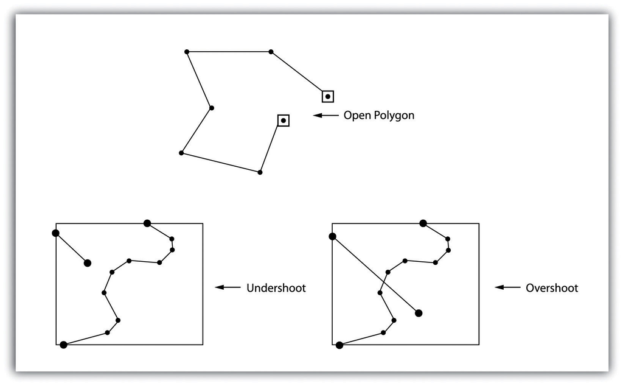

Topology Errors - Saylor Acad.

We’ll use `st_is_valid()` (a *predicate*) to check this, but fixing can be tricky

## Fixing Problematic Topology

- `st_make_valid()` (a *transformer*) for simple cases
- `st_buffer` (also a *transformer*) with `dist=0`

## Fixing geometries

- When `all(st_is_valid(your.shapefile))` returns `FALSE`
- `st_make_valid` has two methods:
  - original converts rings into noded lines and extracts polygons
  - structured makes rings valid first then merges/subtracts from existing polgyons

````markdown
```{r}
library(sf)
x = st_sfc(st_polygon(list(rbind(c(0,0),c(0.5,0),c(0.5,0.5),c(0.5,0),c(1,0),c(1,1),c(0,1),c(0,0)))))
st_is_valid(x)
```
````

```
[1] FALSE
```

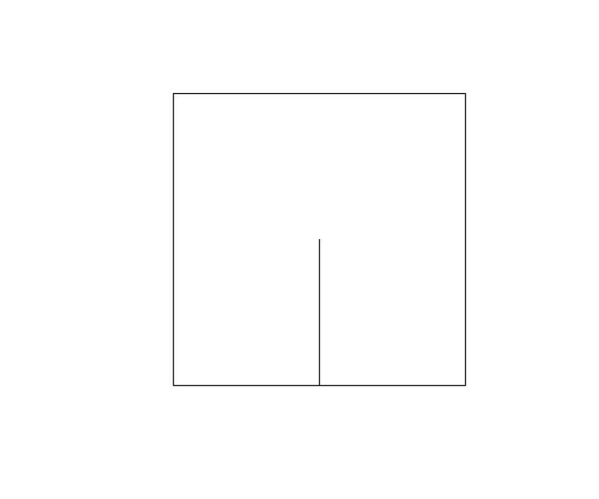

## Fixing geometries with `st_make_valid`

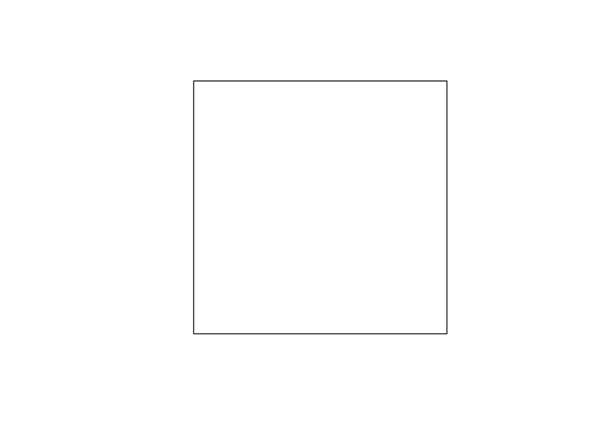

````markdown
```{r}
y <- x %>% st_make_valid()
st_is_valid(y)
```
````

```
[1] TRUE
```

## Fixing Geometries with `st_buffer`

-`st_buffer` enforces valid geometries as an output

- Setting a 0 distance buffer leaves most geometries unchanged
- Not all transformations do this

````markdown
```{r}
z <- x %>% st_buffer(., dist=0)

st_is_valid(z)
```
````

```
[1] TRUE
```

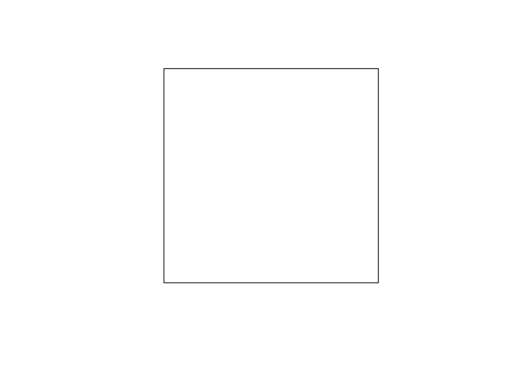

## Revisiting the Raster Data Model

- **Vector data** describe the “exact” locations of features on a landscape (including a Cartesian landscape)
- **Raster data** represent spatially continuous phenomena (`NA` is possible)
- Depict the alignment of data on a regular lattice (often a square)
  - Operations mimic those for `matrix` objects in `R`
- Geometry is implicit; the spatial extent and number of rows and columns define the cell size

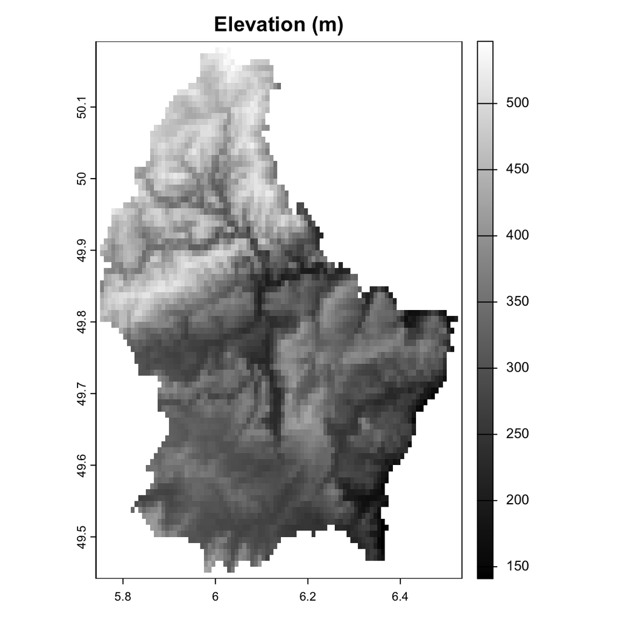

## Rasters with `terra`

- syntax is different for `terra` compared to `sf`
- Representation in `Environment` is also different
- Can break pipes, **Be Explicit**

# Rasters by Construction

## Rasters by Construction

```r
mtx <- matrix(1:16, nrow=4)
mtx
```

```
     [,1] [,2] [,3] [,4]
[1,]    1    5    9   13
[2,]    2    6   10   14
[3,]    3    7   11   15
[4,]    4    8   12   16
```

```r
rstr <- terra::rast(mtx)
rstr
```

```
class       : SpatRaster
size        : 4, 4, 1  (nrow, ncol, nlyr)
resolution  : 1, 1  (x, y)
extent      : 0, 4, 0, 4  (xmin, xmax, ymin, ymax)
coord. ref. :
source(s)   : memory
name        : lyr.1
min value   :     1
max value   :    16
```

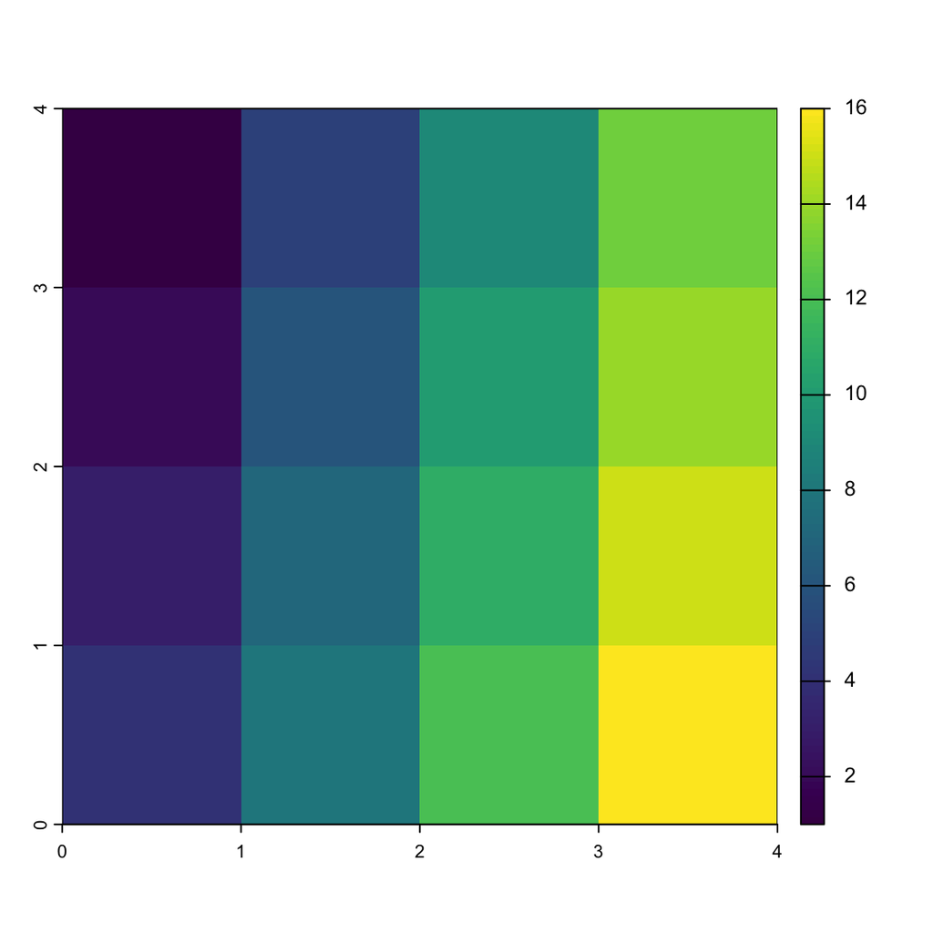

Note: you must have `raster` or `terra` loaded for `plot()` to work on `Rast*` objects; otherwise you get `Error in as.double(y) : cannot coerce type 'S4' to vector of type 'double'`

## Rasters by Construction: Origin

- Origin defines the location of the intersection of the x and y axes

```r
r <- rast(xmin=-4, xmax = 9.5, ncols=10)
r[] <- runif(ncell(r))
origin(r)
```

```
[1] 0.05 0.00
```

```r
r2 <- r
origin(r2) <- c(2,2)
```

[figure not shown]

## Rasters by Construction: Resolution

- Geometry is implicit; the spatial extent and number of rows and columns define the cell size
- **Resolution** (`res`) defines the length and width of an individual pixel

```r
r <- rast(xmin=-4, xmax = 9.5,
          ncols=10)
res(r)
```

```
[1] 1.35 1.00
```

```r
r2 <- rast(xmin=-4, xmax = 5,
           ncols=10)
res(r2)
```

```
[1] 0.9 1.0
```

```r
r <- rast(xmin=-4, xmax = 9.5,
          res=c(0.5,0.5))
ncol(r)
```

```
[1] 27
```

```r
r2 <- rast(xmin=-4, xmax = 9.5,
           res=c(5,5))
ncol(r2)
```

```
[1] 3
```

# Predicates and measures in `terra`

## Extending predicates

- **Predicates**: evaluate a logical statement asserting that a property is `TRUE`
- `terra` does not follow the same hierarchy as `sf` so a little trickier

## Unary predicates in `terra`

- Can tell us qualities of a raster dataset
- Many similar operations for `SpatVector` class (note use of `.`)

| predicate | asks… |
| --- | --- |
| `is.lonlat` | Does the object have a longitude/latitude CRS? |
| `inMemory` | is the object stored in memory? |
| `is.factor` | Are there categorical layers? |
| `hasValues` | Do the cells have values? |

## Unary predicates in `terra`

- `global`: tests if the raster covers all longitudes (from -180 to 180 degrees) such that the extreme columns are in fact adjacent

```r
r <- rast()
is.lonlat(r)
```

```
[1] TRUE
```

```r
is.lonlat(r, global=TRUE)
```

```
[1] TRUE
```

- `perhaps`: If TRUE and the crs is unknown, the method returns TRUE if the coordinates are plausible for longitude/latitude

```r
crs(r) <- ""
is.lonlat(r)
```

```
[1] NA
```

```r
is.lonlat(r, perhaps=TRUE, warn=FALSE)
```

```
[1] TRUE
```

```r
crs(r) <- "+proj=lcc +lat_1=48 +lat_2=33 +lon_0=-100 +ellps=WGS84"
is.lonlat(r)
```

```
[1] FALSE
```

## Binary predicates in `terra`

- Take exactly 2 inputs, return 1 matrix of cell locs where value is `TRUE`
- `adjacent`: identifies cells adajcent to a set of raster cells

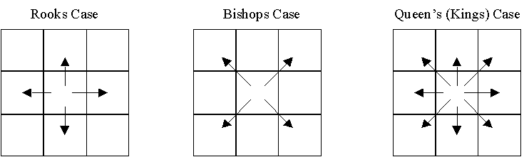

## Unary measures in `terra`

- Slightly more flexible than `sf`
- One result for each layer in a stack

| measure | returns |
| --- | --- |
| `cellSize` | area of individual cells |
| `expanse` | summed area of all cells |
| `values` | returns all cell values |
| `ncol` | number of columns |
| `nrow` | number of rows |
| `ncell` | number of cells |
| `res` | resolution |
| `ext` | minimum and maximum of x and y coords |
| `origin` | the orgin of a `SpatRaster` |
| `crs` | the coordinate reference system |
| `cats` | categories of a categorical raster |

## Binary measures in `terra`

- Returns a matrix or `SpatRaster` describing the measure

| measure | returns |
| --- | --- |
| `distance` | shortest distance to non-NA or vector object |
| `gridDistance` | shortest distance through adjacent grid cells |
| `costDistance` | Shortest distance considering cell-varying friction |
| `direction` | azimuth to cells that are not `NA` |